# Lab 8 Homework Templte: Multiple Regression and Model Selection

Parsa Ara

2023-06-02

# HOMEWORK

Using the airquality data in R, find a best model to predict ozone levels and assess how well your model performs. Treat this lab as a warm-up for your final project: make it look as neat and professional as you can. Remember when plotting residuals to use `par(mfrow = c(2,2))` so all 4 plots appear in one figure, and that you can reset the plotting area using `par(mfrow = c(1,1))`.

## Question 1

Read in the air quality data and visualize it. What are your potential predictors? What are some potential random factors? Remove any missing data to ‘clean up’ the dataset.

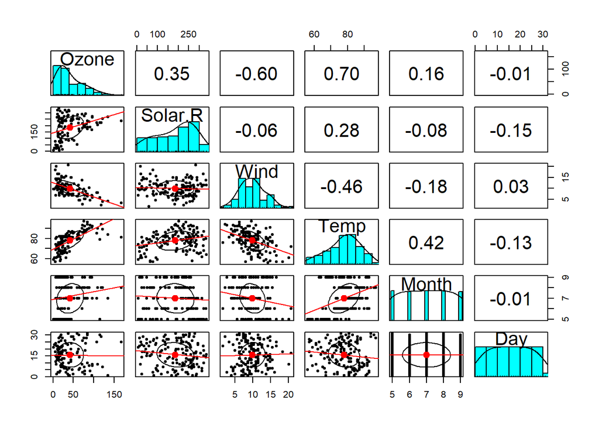

```r
data("airquality")

#Visualizing the data
pairs.panels(airquality, lm = TRUE, cor = T)
```

```r
# Identify potential predictors
potential_predictors <- c("Solar.R", "Wind", "Temp")

# Identify potential random factors
potential_random_factors <- c("Month", "Day")

# Clean up the dataset by removing missing data
airquality <- na.omit(airquality)
```

Potential predictors are *Solar.R*, *Wind* and *Temp* while ome potential random factors are *Month* and *Day*.

## Question 2

Check the linear model assumptions (multicollinearity, linear relationship with the response, normality and homoscedasticity of residuals). Transform any data that violates assumptions (remember, not all predictors need to be normal as long as the model residuals are normal). Check for any influential outliers. Describe what you find.

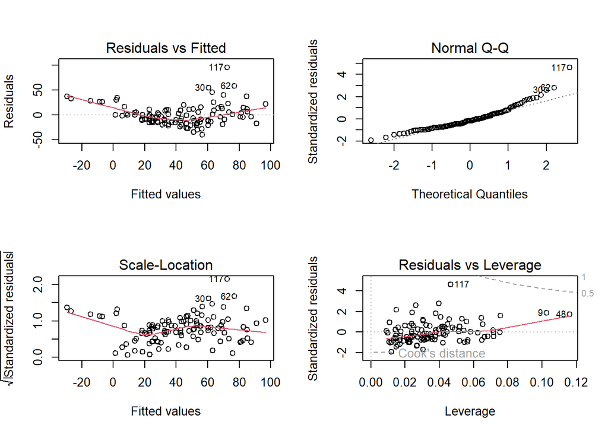

```r
# Fit a linear regression model

lm_model_1 <- lm(Ozone ~ Solar.R + Wind + Temp, data = airquality)

# Check assumptions and identify violations
par(mfrow = c(2, 2))

# plotting  assumptions
plot(lm_model_1)
```

```r
# Reset plotting area
par(mfrow = c(1, 1))
```

There are no observations with a Cook’s distance exceeding the threshold of 1, indicating the absence of influential outliers. It suggests that the model is not unduly influenced by any specific data points.

## Question 3

Fit a linear model with one predictor. Check its residuals for normality.

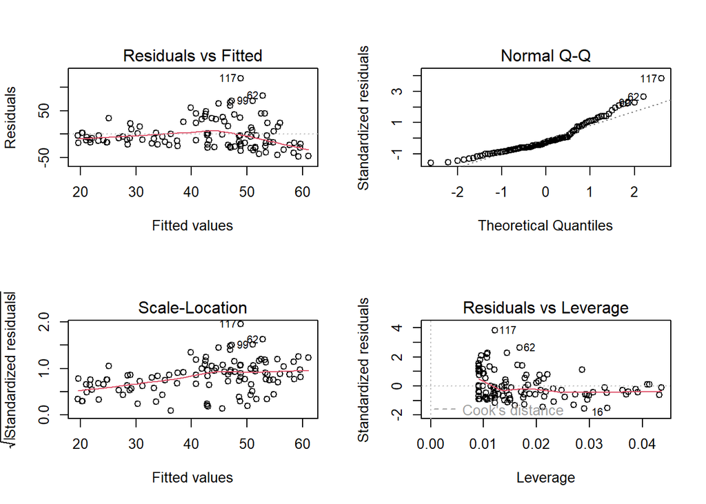

```r
## code to answer this question here
# Fit the linear model with one predictor
lm_model <- lm(Ozone ~ Solar.R, data =airquality)

# Check the normality of residuals using a Q-Q plot
par(mfrow = c(2, 2))
plot(lm_model)
```

## Question 4

Fit a least two other models with different combinations of predictors (no random effects!). State whether you are including random effects or interaction terms. Check the residuals for normality.

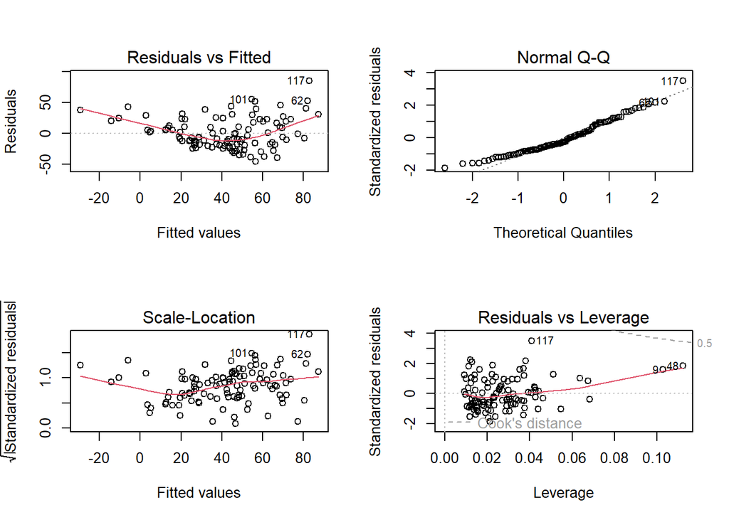

```r
# Fit Model 1 with a different combination of predictors
lm_model1 <- lm(Ozone ~ Solar.R + Wind, data = airquality)

#Look at diagnostic plots for each model
par(mfrow = c(2,2))
# Check the normality of residuals using a Q-Q plot
plot(lm_model1)
```

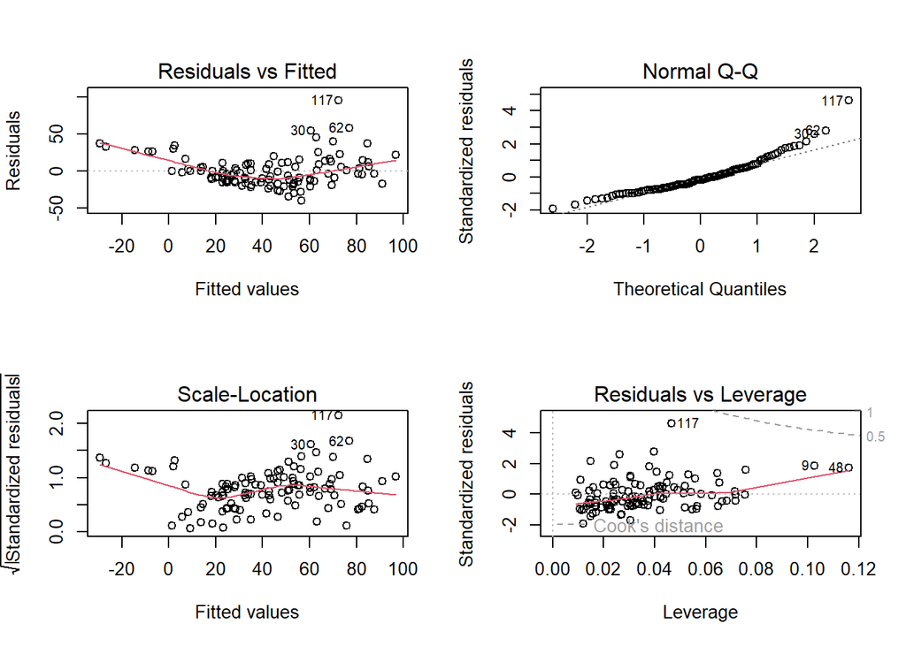

```r
# Fit Model 2 with another combination of predictors
lm_model2 <- lm(Ozone ~ Solar.R + Wind+ Temp, data = airquality)
plot(lm_model2)
```

I have not included random effects or interaction terms in the models.

## Question 5.

Create a table of results to compare your **linear** models using AIC, BIC, and adjusted R-squared. Include the degrees of freedom of each model in the table so that you can consider parsimony in your final decision. Based on this table choose the best model and explain why this was your choice.

```r
## code to answer this question here
## make a list of all the models
models <- list(lm_model,lm_model1,lm_model2)

## make a list of df, AIC, BIC, Rsq and adj-Rsq for each model
## map and map_dbl apply functions to each element of a vector
### degrees of freedom
df <- models %>% map_dbl('df.residual') #model$df.residual tell you df of each model individually
## AIC
aic <- models %>% map_dbl(AIC) #AIC(model) tells you AIC of each model individually
## BIC
bic <- models %>% map_dbl(BIC)
##rsq
rsq <- models %>% map(summary) %>% map_dbl('r.squared')
## adjusted rsq
adj.rsq <- models %>% map(summary) %>% map_dbl('adj.r.squared')

results <- data.frame(model = c("lm_model","lm_model1","lm_model2"),
                      df = df,
                      AIC = aic,
                      BIC = bic,
                      Rsq = rsq,
                      Adj.Rsq = adj.rsq)

## print the dataframe in a pretty kable format
kable(results, digits = 2, align = "c")
```

| model | df | AIC | BIC | Rsq | Adj.Rsq |
| --- | --- | --- | --- | --- | --- |
| lm_model | 109 | 1083.71 | 1091.84 | 0.12 | 0.11 |
| lm_model1 | 108 | 1033.82 | 1044.65 | 0.45 | 0.44 |
| lm_model2 | 107 | 998.72 | 1012.26 | 0.61 | 0.59 |

Based on these observations, it appears that **lm_model2** is the best model among the three. It has the lowest AIC and BIC values, the highest adjusted R-squared, and a relatively fewer number of degrees of freedom. This suggests that **lm_model2** provides the best balance between goodness of fit and simplicity.

## Question 6

What does your best model predict Ozone to be on July 1st when the Solar R is 200 Langleys, Wind is 9 mph, and Temperature is 84 degrees F? *Hint: if you used a transformation in your model either back transform or report the results with the transformation*

```r
## code to answer this question here
# new dataframe with  new observation

airquality2 <- data.frame(Solar.R = 200,
                               Wind = 9,
                               Temp = 84)
# Predict Ozone using the best model (lm_model2)
prediction <- predict(lm_model2,newdata = airquality2)
print(prediction)
```

```
##        1
## 56.39552
```

56.3955